# lab1

#### Consider a loaded die that has a 10% chance of rolling a 1-5 and a 50% chance of rolling a 6.

Define a vector of roll outcome probabilities.

```r
probabilityVector <- c(0.1, 0.1, 0.1, 0.1, 0.1, 0.5)
```

Define a function to find the mean outcome, given a vector of outcome probabilities.

```r
loadedMean <- function(probabilityVector) {
  return(sum(probabilityVector * c(1,2,3,4,5,6)))
}
```

```r
loadedVariance <- function(probabilityVector) {
  return(sum(probabilityVector * (c(1,2,3,4,5,6) - loadedMean(probabilityVector))^2))
}
```

Given the above probabilityVector, the **expected mean and variance** of roll outcomes for the loaded die are:

```r
expectedMean = loadedMean(probabilityVector)
expectedVariance = loadedVariance(probabilityVector)
```

- Mean: 4.5
- Variance: 3.25

Define a function that simulates a single role of a die, given a role outcome probability vector.

```r
rollDieOnce <- function(probabilityVector) {
  probabilityIntervals <- vector()
  for (i in seq(1:length(probabilityVector))) {
    probabilityIntervals <- c(probabilityIntervals, sum(probabilityVector[1:i]))
  }
  return(length(probabilityVector) - sum(probabilityIntervals >= runif(1)) + 1)
}
```

Define a function that simulates numberRolls number of rolls, given a role outcome probability vector.

```r
rollDie <- function(probabilityVector, numberRolls) {
  rolls <- vector()
  for (i in seq(numberRolls)) {
    rolls <- c(rolls, rollDieOnce(probabilityVector))
  }
  return(rolls)
}
```

**Generate a vector** containing 10,000 sample rolls of the loaded die.

```r
sampleRolls <- rollDie(probabilityVector, 10000)
head(sampleRolls)
```

```
## [1] 6 6 6 3 6 4
```

- The length of sampleRolls is 10000

Verify the observed roll outcome probabilities are similar to what is expected, based in the input probability vector.

```r
for (i in sort(unique(sampleRolls))) {
  print(paste0("P(", i, ")", " = ", sum(sampleRolls == i) / length(sampleRolls)))
}
```

```
## [1] "P(1) = 0.1011"
## [1] "P(2) = 0.0984"
## [1] "P(3) = 0.101"
## [1] "P(4) = 0.1021"
## [1] "P(5) = 0.1006"
## [1] "P(6) = 0.4968"
```

Due to the unequal distribution of roll outcome probabilities, **the observed sample roll outcomes do not resemble a uniform distribution**.

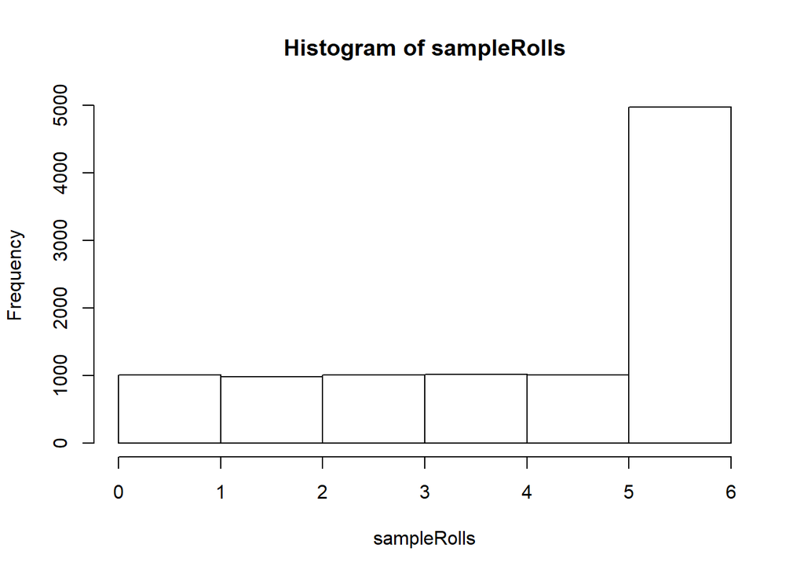

```r
hist(sampleRolls, breaks = seq(0,6))
```

Determine the mean and variance for each of a vector of increasing sample rolls.

```r
trialSizes <- c(5, 10, 15, 20, 25, 30, 40, 50, 100, 200, 300, 400, 500, 1000, 2000, 3000, 4000, 5000, 10000, 20000, 30000, 100000)
means <- vector(mode = "double", length=length(trialSizes))
variances <- vector(mode = "double", length=length(trialSizes))

for (i in 1:length(trialSizes)) {
  rolls <- rollDie(probabilityVector, trialSizes[i])
  means[i] = mean(rolls)
  variances[i] = var(rolls)
}
```

Plot the observed means, as determined above.

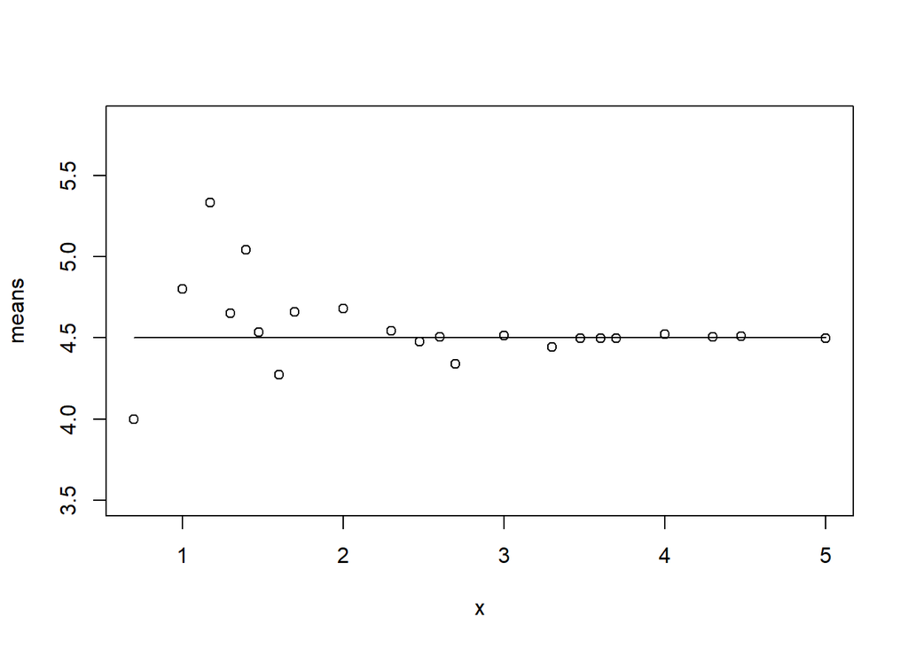

```r
x <- log10(trialSizes)
plot(x, means, ylim = c(min(means) - 0.5, max(means) + 0.5))
lines(x, rep(expectedMean, length(trialSizes)))
```

Plot the observed variances, as determined above.

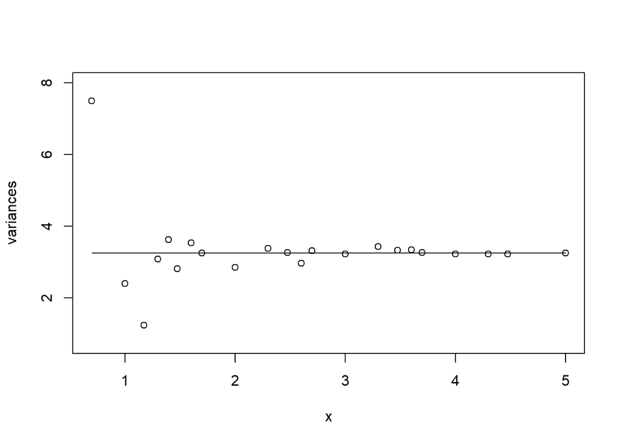

```r
plot(x, variances, ylim = c(min(variances) - 0.5, max(variances) + 0.5))
lines(x, rep(expectedVariance, length(trialSizes)))
```

By the law of large numbers, the observed **mean and variance converge** at the respective expected values (within a 1% variance tolerance), given the following number of rolls:

Define a function to find the variance of a sample around an expected mean.

```r
varFromExpectedMean <- function(v, expectedMean) {
  variance = 0
  for (i in v) {
    variance = variance + (i - expectedMean)**2 / length(v)
  }
  return(variance)
}
```

Define a function to find the index of the first range with a variance below a specified threshold, given a vector and interval size.

```r
convergenceIndex <- function(v, minVariance, intervalSize, expectedMean) {
  for (i in seq(1:(length(v) - intervalSize))) {
    if (varFromExpectedMean(v[i:(i + intervalSize)], expectedMean) < minVariance) {
      return(i)
    }
  }
  return(NULL)
}
```

- Mean convergence: 200 rolls
- Variance convergence: 500 rolls